# Taller No. 2

Kevin Pelaez - Juan Diego Osorio

28 de octubre de 2018

## PUNTO #1

1. Considere un cuerpo con temperatura interna **T**𝑇 el cual se encuentra en un ambiente con temperatura constante**Te**. Suponga que su masa **m**𝑚 concentrada en un solo punto. Entonces la transferencia de calor entre el cuerpo y el entorno externo puede ser descrita con la ley de Stefan-Boltzmann:

$$v(t) = εγS(T^4(t)-T_e^4)$$
Donde, **t** es tiempo y **ε** es la constante de Boltzmann $(ε = 5.6x10^-8 J/m^2K^2s)$, **γ** es la constante de “Emisividad” del cuerpo, **S** el área de superficie y **v** es la tasa de transferencia de calor. La tasa de variacion de la energía $dT/dt = -v(t)/mC$ (C indica el calor específico del material que constituye el cuerpo). En consecuencia,

$$dT/dt = -εγS(T^4(t)-T_e^4)/mC$$
Usando el método de Euler (en R) y 20 intervalos iguales y t variando de 0 a 200 segundos, resuelva numéricamente la ecuación, si el cuerpo es un cubo de lados de longitud 1m y masa igual a 1Kg. Asuma, que T0 = 180K, Te = 200K, g = 0.5 y C = 100J/(Kg/K). Hacer una representación gráfica del resultado.

|  | X | Y |
| --- | --- | --- |
| 21 | 200 | 192.6369 |

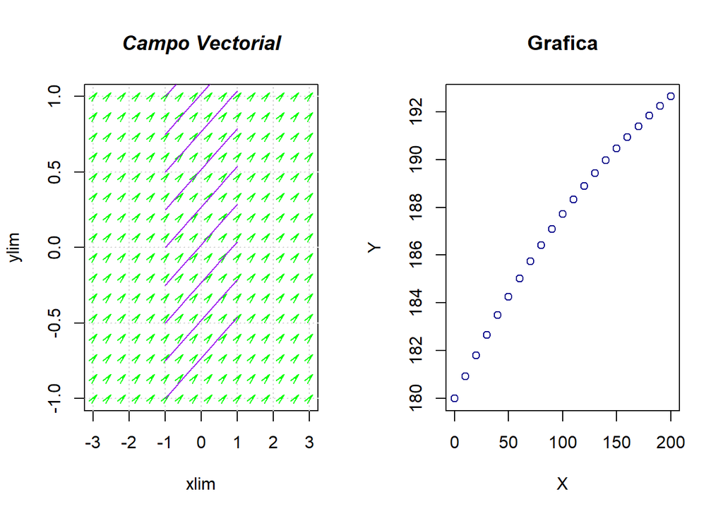

## PUNTO #2

2. Obtenga cinco puntos de la solución de la ecuación, utilizando el método de Taylor (los tres primeros términos)con h=0.1 implemente en R

$$dy/dx - (x+y) = 1 - x^2; y(0) =1$$

Grafique su solución y compare con la solución exacta, cuál es el error de truncamiento en cada paso

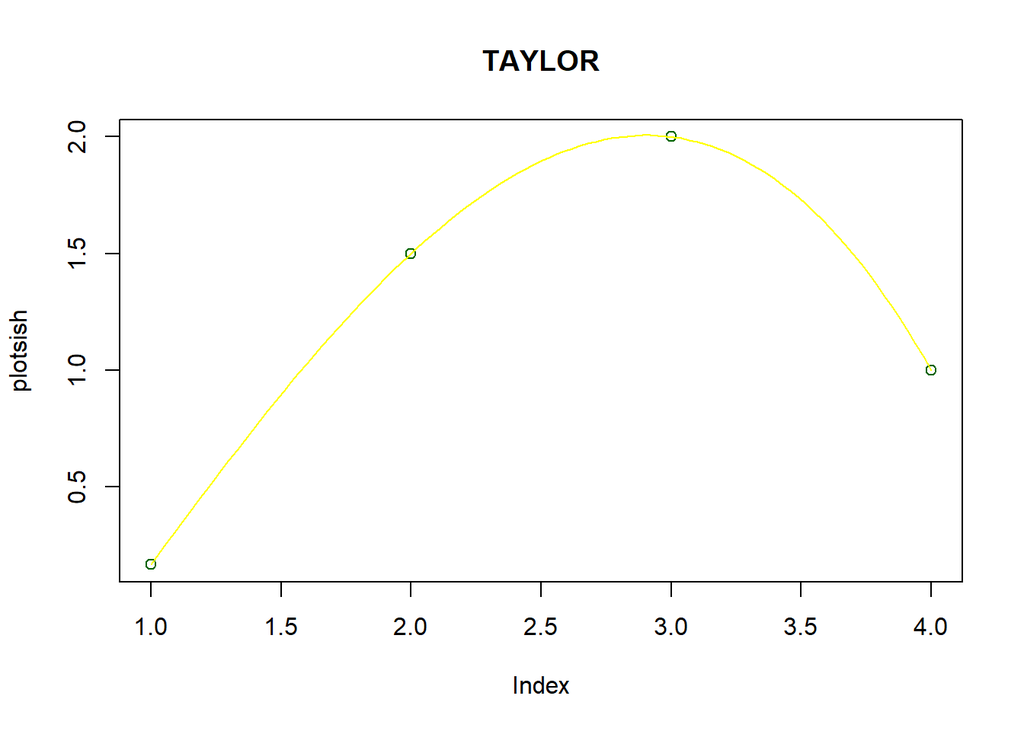

```r
funcion4punto <- function(x){
  exp(x) * (x^2* exp(-x) + x* exp(-x) + 1)
}

num <- seq(1:4)
plotsish <- c(taylor(funcion4punto, x0=0, n = 3))

plot(plotsish, col = "darkgreen", main = "TAYLOR")

poliajuste <- poly.calc(num,plotsish)
curve(poliajuste,add = TRUE, col = "yellow")
```

## PUNTO #3

3. Obtenga 20 puntos de la solución de la ecuación, utilizando el método de Euler (los tres primeros términos) con h=0.1
   $$dy/dx - (x+y) = 1 - x^2; y(0) =1$$
   Grafique su solución y compare con la solución exacta, cuál es el error de truncamiento en cada paso

```r
metodoEuler <- function(f, h, xi, yi, xf)
{
  N = (xf - xi) / h
  x = y = numeric(N+1)
  x[1] = xi;
  y[1] = yi;
  i = 1
  while (i <= N)
  {
    x[i+1] = x[i]+h
    y[i+1] = y[i]+(h*f(x[i],y[i]))
    i = i+1
  }
  return (data.frame(X = x, Y = y))
}

funcion3punto <- function(x,y) { exp(x) * (x^2* exp(-x) + x* exp(-x) + 1)}

e1 = metodoEuler(f, 0.1, 0, 1, 2)

e1[nrow(e1),]
```

|  | X | Y |
| --- | --- | --- |
| 21 | 2 | 1.5376 |

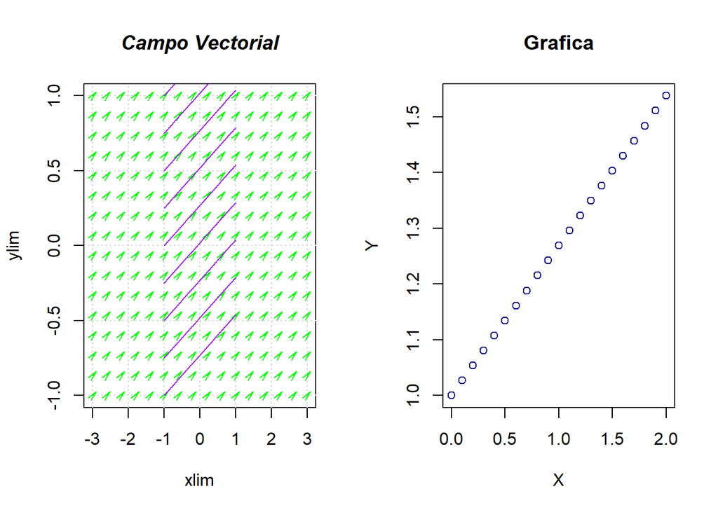

```r
par(mfrow = c(1,2))

xx <- c(-3, 3); yy <- c(-1, 1)
vectorfield(f, xx, yy, scale = 0.1)
for (xs in seq(-1, 1, by = 0.25))
{
  sol <- rk4(f, -1, 1, xs, 100)
  lines(sol$x, sol$y, col="purple")
}
title(main="Campo Vectorial", col.main="black", font.main=4)

plot(e1, col = "darkblue", main = "Grafica")
```

## PUNTO #4

Implemente en R el siguiente algoritmo y aplíquelo para resolver la ecuación anterior

1. Defina h y la cantidad de puntos a calcular m
2. Defina f(x,y) y la condicion iniccial (x0,y0)
3. para i =12, …, m
4. K1= hf(xi, yi)
5. k2 = hf(xi + h, yi +h)
6. yi+1 = yi + 1/2 (k1 + k2)
7. xi+1 = xi + h
8. fin

```r
funcion4punto <- function(x,y){
  return  (exp(x) * (x^2* exp(-x) + x* exp(-x) + 1))
}

m <- 5

h <- 0.1
 x0 <- 1
 y0 <- 0
for (i  in 1:m){
  k1 <- h * funcion4punto(x0, y0)
  k2 <- h * funcion4punto(x0 + h, y0+h)
  y0 <- y0 + 0.5 * (k1 + k2)
  x0 <- x0 + h
 }
```

## PUNTO #5

Utilizar la siguiente variación en el método de Euler, para resolver una ecuación diferencial ordinaria de primer orden, la cual calcula el promedio de las pendientes en cada paso

$$

y_{i+1} = y_i + h/2 f((x_i,y_i) + f(x_{i+1}, y_{i+1}) )

$$

Implemente un código en R, para este método y obtenga 10 puntos de la solución con h=0.1, grafíquela y compárela con el método de Euler:

$$dy/dx - (x+y) = 1 - x^2 =0 ; y(0) =1$$

```r
variacionMetodoEuler <- function(f, h, xi, yi, xf)
{
  N = (xf - xi) / h
  x = y = numeric(N+1)
  x[1] = xi;
  y[1] = yi;
  i = 1
  while (i <= N)
  {
    x[i+1] = x[i]+h
    y[i+1] = y[i]+(h/2)*(f(x[i],y[i]))
    i = i+1
  }
  return (data.frame(X = x, Y = y))
}
f <- function(x,y) {x+y-1+x^2}

e1 = variacionMetodoEuler(f, 0.1, 0, 1, 1)

e1[nrow(e1),]
```

|  | X | Y |
| --- | --- | --- |
| 11 | 1 | 1.414725 |

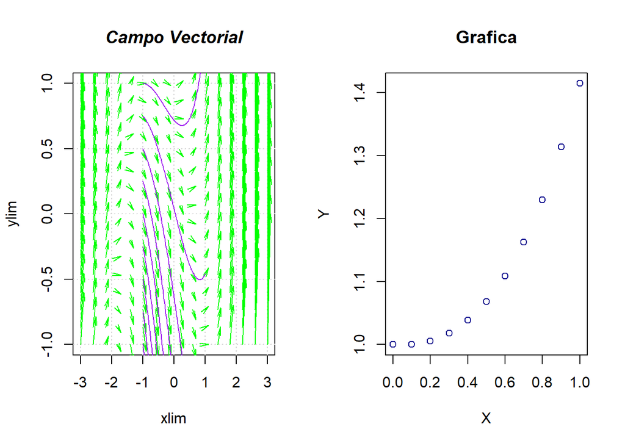

```r
par(mfrow = c(1,2))

xx <- c(-3, 3); yy <- c(-1, 1)
vectorfield(f, xx, yy, scale = 0.1)
for (xs in seq(-1, 1, by = 0.25))
{
  sol <- rk4(f, -1, 1, xs, 100)
  lines(sol$x, sol$y, col="purple")
}
title(main="Campo Vectorial", col.main="black", font.main=4)

plot(e1, col = "darkblue", main = "Grafica")
```

## PUNTO #7

Pruebe el siguiente código en R del método de Runge Kutta de tercer y cuarto orden y obtenga 10 puntos de la solución con h=0.1, grafíquela y compárela con el método de Euler:

$$dy/dx - (x+y) = 1 - x^2 =0 ; y(0) =1$$

```r
f<-function(fcn,x,y){
  return(eval(fcn))
}

obtenerErrorAbsoluto<-function(x,y){
  solucion=exp(x)*((-x*exp(-x))-exp(-x)+2)
  return(abs(y-solucion))
}

graficarCampoPendiente<-function(x0, xn, y0, yn, fcn, numpendientes, metodo){
  apma1 <- function(t, y, parameters){
    a <- parameters[1]
    dy <- a*(f(fcn, t, y))
    list(dy)
  }
  apma1.flowField <- flowField(apma1, x = c(x0, xn),
                               y   = c(y0, yn), parameters = c(1),
                               points = numpendientes, system = "one.dim",
                               add = FALSE, xlab = "x", ylab = "y",
                               main = metodo)
  grid()
}

graficarSolucionNumerica<-function (x, y){
  points (x, y, pch=20, col="blue")
  for (i in 2:length(x)){
    segments(x[i-1], y[i-1], x[i], y[i], col="red")
  }
}

Rrk4<-function(dy, ti, tf, y0, h, graficar=TRUE, numpendientes=10){
  t<-seq(ti, tf, h)
  y<-c(y0)
  cat("x    |y         |k1        |k2        |k3        |k4       |error absoluto\n")
  for(i in 2:length(t)){
    k1=h*f(dy, t[i-1], y[i-1])
    k2=h*f(dy, t[i-1]+h/2, y[i-1]+k1*(0.5))
    k3=h*f(dy, t[i-1]+h/2, y[i-1]+k2*(0.5))
    k4=h*f(dy, t[i-1]+h, y[i-1]+k3)
    y<-c(y, y[i-1]+1/6*(k1+2*k2+2*k3+k4))
    cat(t[i-1]," | ", y[i-1]," | ",k1," | ",k2," | ",k3," | ",k4," | ",obtenerErrorAbsoluto(t[i-1],y[i-1]),"\n")
  }
  if (graficar){
    graficarCampoPendiente(min(t), max(t), min(y), max(y), dy, numpendientes, "RK4")
    graficarSolucionNumerica(t, y)
  }
  rta<-list(w=y, t=t)
}

rk3<-function(dy, ti, tf, y0, h, graficar=TRUE, numpendientes=10){
  t<-seq(ti, tf, h)
  y<-c(y0)
  cat("x    |y         |k1         |k2        |k3       |error absoluto\n")
  for(i in 2:length(t)){
    k1=h*f(dy, t[i-1], y[i-1])
    k2=h*f(dy, t[i-1]+h/2, y[i-1]+k1*(0.5))
    k3=h*f(dy, t[i-1]+h, y[i-1]-k1+2*k2)
    y<-c(y, y[i-1]+1/6*(k1+4*k2+k3))
    cat(t[i-1]," | ", y[i-1]," | ",k1," | ",k2," | ",k3," | ",obtenerErrorAbsoluto(t[i-1],y[i-1]),"\n")
  }
  if (graficar){
    graficarCampoPendiente(min(t), max(t), min(y), max(y), dy, numpendientes, "RK3")
    graficarSolucionNumerica(t, y)
  }
  rta<-list(w=y, t=t)
}

r<-Rrk4(expression(x+y+1-x^2), 0, 1, 1, 0.1)
```

```
## x    |y         |k1        |k2        |k3        |k4       |error absoluto
## 0  |  1  |  0.2  |  0.21475  |  0.2154875  |  0.2305488  |  0
## 0.1  |  1.215171  |  0.2305171  |  0.2457929  |  0.2465567  |  0.2621727  |  0.1048288
## 0.2  |  1.461402  |  0.2621402  |  0.2779972  |  0.2787901  |  0.2950192  |  0.2185966
## 0.3  |  1.739858  |  0.2949858  |  0.3114851  |  0.31231  |  0.3292168  |  0.3401402
## 0.4  |  2.051823  |  0.3291823  |  0.3463914  |  0.3472519  |  0.3649075  |  0.4681739
## 0.5  |  2.398719  |  0.3648719  |  0.3828655  |  0.3837652  |  0.4022485  |  0.6012768
## 0.6  |  2.782116  |  0.4022116  |  0.4210722  |  0.4220152  |  0.4414132  |  0.7378787
## 0.7  |  3.20375  |  0.441375  |  0.4611937  |  0.4621846  |  0.4825934  |  0.8762442
## 0.8  |  3.665537  |  0.4825537  |  0.5034314  |  0.5044753  |  0.5260012  |  1.014455
## 0.9  |  4.169599  |  0.5259599  |  0.5480078  |  0.5491102  |  0.5718709  |  1.150392
```

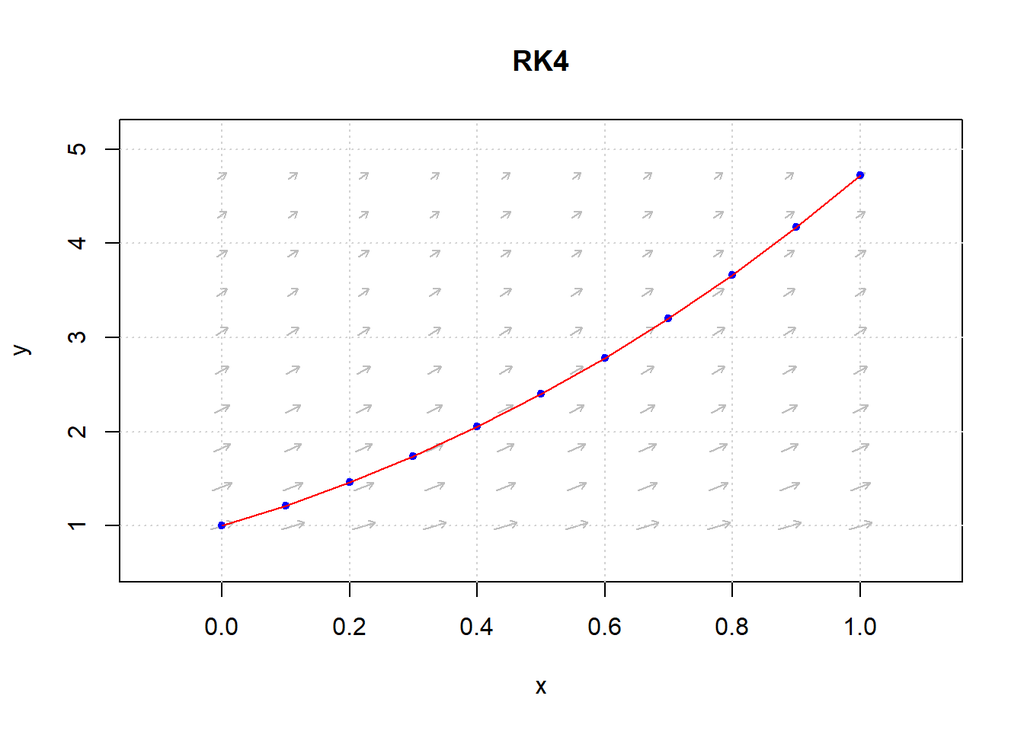

```r
r2<-rk3(expression(x+y+1-x^2), 0, 1, 1, 0.1)
```

```
## x    |y         |k1         |k2        |k3       |error absoluto
## 0  |  1  |  0.2  |  0.21475  |  0.23195  |  0
## 0.1  |  1.215158  |  0.2305158  |  0.2457916  |  0.2636226  |  0.1048165
## 0.2  |  1.461376  |  0.2621376  |  0.2779945  |  0.2965227  |  0.2185703
## 0.3  |  1.739816  |  0.2949816  |  0.3114806  |  0.3307795  |  0.3400979
## 0.4  |  2.051763  |  0.3291763  |  0.3463851  |  0.3665357  |  0.4681134
## 0.5  |  2.398638  |  0.3648638  |  0.382857  |  0.4039488  |  0.6011956
## 0.6  |  2.782012  |  0.4022012  |  0.4210612  |  0.4431933  |  0.737774
## 0.7  |  3.203618  |  0.4413618  |  0.4611799  |  0.4844616  |  0.8761127
## 0.8  |  3.665375  |  0.4825375  |  0.5034144  |  0.5279667  |  1.014293
## 0.9  |  4.169402  |  0.5259402  |  0.5479872  |  0.5739437  |  1.150196
```

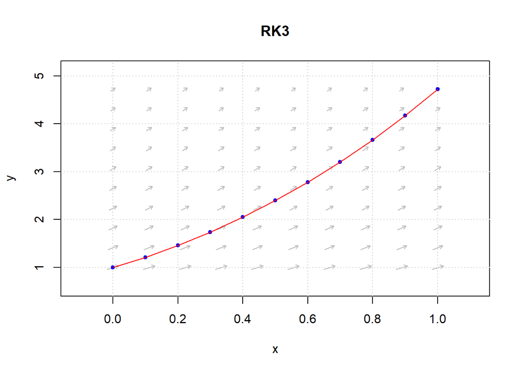